Frederico Karklin

Back to Projects

# Análise de acidentes de Trânsito - Detran 2024

[figure not shown]

# Manipulação e análise de dados com R - Trabalho prático da disciplina Probabilidade e Estatística para Análise de Dados

Importando o dataset e as libraries necessárias em R:

```r
install.packages("ggplot2")
library(ggplot2)
install.packages("dplyr")
library(dplyr)


dataset <- read.csv("/content/datatran2024.csv", sep = ";", header = TRUE, fileEncoding = "latin1", stringsAsFactors = FALSE)
```

Explorando características do dataset:

```r
# Explorando as características do dataset

head(dataset)

str(dataset)

summary(dataset)
```

A data.frame: 6 × 30

|  | id <chr> | data_inversa <chr> | dia_semana <chr> | horario <chr> | uf <chr> | br <int> | km <chr> | municipio <chr> | causa_acidente <chr> | tipo_acidente <chr> | ⋯ | feridos_graves <int> | ilesos <int> | ignorados <int> | feridos <int> | veiculos <int> | latitude <chr> | longitude <chr> | regional <chr> | delegacia <chr> | uop <chr> |
| --- | --- | --- | --- | --- | --- | --- | --- | --- | --- | --- | --- | --- | --- | --- | --- | --- | --- | --- | --- | --- | --- |
| 1 | 571789 | 01/01/2024 | segunda-feira | 03:56:00 | ES | 101 | 38 | CONCEICAO DA BARRA | Ultrapassagem Indevida | Colisão lateral sentido oposto | ⋯ | 1 | 1 | 1 | 1 | 3 | -18,48261 | -39,92379 | SPRF-ES | DEL04-ES | UOP02-DEL04-ES |
| 2 | 571804 | 01/01/2024 | segunda-feira | 04:50:00 | PI | 343 | 185 | PIRIPIRI | Manobra de mudança de faixa | Colisão frontal | ⋯ | 0 | 1 | 0 | 0 | 2 | -4,29603281 | -41,76732659 | SPRF-PI | DEL02-PI | UOP01-DEL02-PI |
| 3 | 571806 | 01/01/2024 | segunda-feira | 04:30:00 | BA | 116 | 578 | BREJOES | Ingestão de álcool pelo condutor | Colisão frontal | ⋯ | 0 | 1 | 2 | 0 | 4 | -13,07158302 | -39,9611107 | SPRF-BA | DEL03-BA | UOP02-DEL03-BA |
| 4 | 571818 | 01/01/2024 | segunda-feira | 06:30:00 | SE | 101 | 18 | MALHADA DOS BOIS | Reação tardia ou ineficiente do condutor | Saída de leito carroçável | ⋯ | 1 | 0 | 2 | 1 | 3 | -10,35601949 | -36,90552235 | SPRF-SE | DEL02-SE | UOP02-DEL02-SE |
| 5 | 571838 | 01/01/2024 | segunda-feira | 05:00:00 | MT | 364 | 240 | RONDONOPOLIS | Condutor deixou de manter distância do veículo da frente | Colisão traseira | ⋯ | 0 | 2 | 1 | 0 | 3 | -16,17914141 | -54,78905337 | SPRF-MT | DEL02-MT | UOP01-DEL02-MT |
| 6 | 571855 | 01/01/2024 | segunda-feira | 11:50:00 | MG | 251 | 447 | GRAO MOGOL | Velocidade Incompatível | Colisão traseira | ⋯ | 0 | 1 | 1 | 1 | 3 | -16,43408996 | -43,27992195 | SPRF-MG | DEL12-MG | UOP01-DEL12-MG |

```
'data.frame':	60365 obs. of  30 variables:
 $ id                    : chr  "571789" "571804" "571806" "571818" ...
 $ data_inversa          : chr  "01/01/2024" "01/01/2024" "01/01/2024" "01/01/2024" ...
 $ dia_semana            : chr  "segunda-feira" "segunda-feira" "segunda-feira" "segunda-feira" ...
 $ horario               : chr  "03:56:00" "04:50:00" "04:30:00" "06:30:00" ...
 $ uf                    : chr  "ES" "PI" "BA" "SE" ...
 $ br                    : int  101 343 116 101 364 251 116 251 116 262 ...
 $ km                    : chr  "38" "185" "578" "18" ...
 $ municipio             : chr  "CONCEICAO DA BARRA" "PIRIPIRI" "BREJOES" "MALHADA DOS BOIS" ...
 $ causa_acidente        : chr  "Ultrapassagem Indevida" "Manobra de mudança de faixa" "Ingestão de álcool pelo condutor" "Reação tardia ou ineficiente do condutor" ...
 $ tipo_acidente         : chr  "Colisão lateral sentido oposto" "Colisão frontal" "Colisão frontal" "Saída de leito carroçável" ...
 $ classificacao_acidente: chr  NA "Com Vítimas Fatais" "Com Vítimas Fatais" "Com Vítimas Feridas" ...
 $ fase_dia              : chr  "Plena Noite" "Amanhecer" "Plena Noite" "Amanhecer" ...
 $ sentido_via           : chr  "Crescente" "Decrescente" "Decrescente" "Crescente" ...
 $ condicao_metereologica: chr  "Céu Claro" "Céu Claro" "Céu Claro" "Céu Claro" ...
```

[output cut: 16 more lines]

```
      id            data_inversa        dia_semana          horario
 Length:60365       Length:60365       Length:60365       Length:60365
 Class :character   Class :character   Class :character   Class :character
 Mode  :character   Mode  :character   Mode  :character   Mode  :character



      uf                  br             km             municipio
 Length:60365       Min.   :  0.0   Length:60365       Length:60365
 Class :character   1st Qu.:101.0   Class :character   Class :character
 Mode  :character   Median :158.0   Mode  :character   Mode  :character
                    Mean   :209.2
                    3rd Qu.:319.0
                    Max.   :495.0
 causa_acidente     tipo_acidente      classificacao_acidente
 Length:60365       Length:60365       Length:60365
 Class :character   Class :character   Class :character
 Mode  :character   Mode  :character   Mode  :character



   fase_dia         sentido_via        condicao_metereologica
 Length:60365       Length:60365       Length:60365
 Class :character   Class :character   Class :character
 Mode  :character   Mode  :character   Mode  :character



  tipo_pista        tracado_via          uso_solo            pessoas
 Length:60365       Length:60365       Length:60365       Min.   : 1.000
 Class :character   Class :character   Class :character   1st Qu.: 2.000
 Mode  :character   Mode  :character   Mode  :character   Median : 2.000
                                                          Mean   : 2.589
                                                          3rd Qu.: 3.000
                                                          Max.   :61.000
     mortos         feridos_leves     feridos_graves        ilesos
 Min.   : 0.00000   Min.   : 0.0000   Min.   : 0.0000   Min.   : 0.000
 1st Qu.: 0.00000   1st Qu.: 0.0000   1st Qu.: 0.0000   1st Qu.: 0.000
 Median : 0.00000   Median : 1.0000   Median : 0.0000   Median : 1.000
 Mean   : 0.08309   Mean   : 0.8728   Mean   : 0.2776   Mean   : 1.043
 3rd Qu.: 0.00000   3rd Qu.: 1.0000   3rd Qu.: 0.0000   3rd Qu.: 1.000
 Max.   :23.00000   Max.   :43.0000   Max.   :30.0000   Max.   :60.000
   ignorados          feridos         veiculos        latitude
 Min.   : 0.0000   Min.   : 0.00   Min.   : 1.000   Length:60365
 1st Qu.: 0.0000   1st Qu.: 1.00   1st Qu.: 1.000   Class :character
 Median : 0.0000   Median : 1.00   Median : 2.000   Mode  :character
 Mean   : 0.4018   Mean   : 1.15   Mean   : 1.995
 3rd Qu.: 1.0000   3rd Qu.: 1.00   3rd Qu.: 2.000
 Max.   :33.0000   Max.   :45.00   Max.   :26.000
  longitude           regional          delegacia             uop
 Length:60365       Length:60365       Length:60365       Length:60365
 Class :character   Class :character   Class :character   Class :character
 Mode  :character   Mode  :character   Mode  :character   Mode  :character
```

# Responder às seguintes questões:

## 1 - Qual foi o estado com o maior número de acidentes?

```
# A tibble: 27 × 2
   uf    total
   <chr> <int>
 1 MG     7597
 2 SC     6916
 3 PR     6213
 4 RJ     5236
 5 RS     4320
 6 SP     4035
 7 BA     3443
 8 GO     2775
 9 PE     2682
10 MT     2131
# ℹ 17 more rows
```

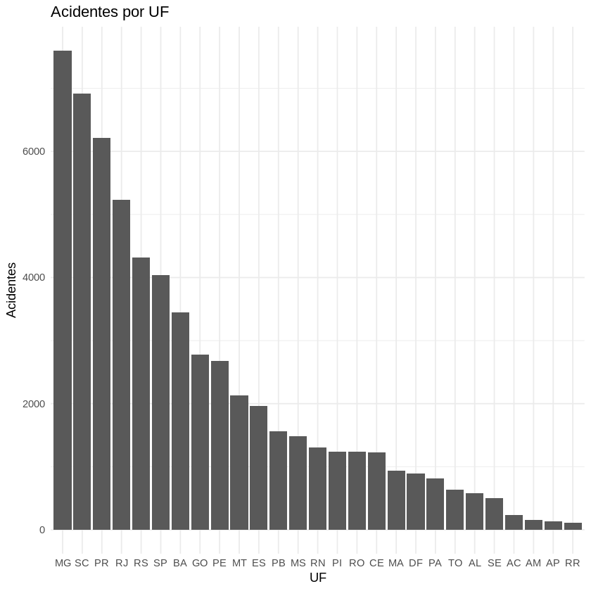

```r
# Contar ocorrências por UF usando dplyr
frequencia_uf <- dataset %>%
  group_by(uf) %>%
  summarise(total = n()) %>%
  arrange(desc(total))

print(frequencia_uf)

# Plot gráfico de barras com ggplot2
ggplot(frequencia_uf, aes(x = reorder(uf, -total), y = total)) +
  geom_bar(stat = "identity") +
  theme_minimal() +
  labs(title = "Acidentes por UF", x = "UF", y = "Acidentes")
```

Após verificar a tabela retornada e o gráfico de barras ordenado descrescentemente, verificamos que Minas Gerais é o estado com mais acidentes veiculares.

## Qual a probabilidade de um acidente ocorrer em condições climáticas claras?

Vamos investigar quais as possibilidades de condição meteorológica contidas na coluna "condicao_metereologica" e a frequência de ocorrências de cada um

```r
# Lista os valores únicos da coluna 'condicao_metereologica'
unique(dataset$condicao_metereologica)

# Contar acidentes por condição meteorológica
frequencia_clima <- dataset %>%
  group_by(condicao_metereologica) %>%
  summarise(total = n()) %>%
  arrange(desc(total))

print(frequencia_clima)
```

1. 'Céu Claro'

2. 'Chuva'

3. 'Sol'

4. 'Nublado'

5. 'Garoa/Chuvisco'

6. 'Ignorado'

7. 'Vento'

8. 'Nevoeiro/Neblina'

9. 'Granizo'

10. 'Neve'

```
# A tibble: 10 × 2
   condicao_metereologica total
   <chr>                  <int>
 1 Céu Claro              39333
 2 Nublado                 8632
 3 Chuva                   5501
 4 Sol                     3299
 5 Garoa/Chuvisco          2098
 6 Ignorado                 783
 7 Nevoeiro/Neblina         613
 8 Vento                    103
 9 Granizo                    2
10 Neve                       1
```

Vamos considerar como "condições climáticas claras" as seguintes condições: "Céu Claro" e "Sol". Vamos também excluir os casos onde a condição climática é "Ignorado".

```r
# Remover registros onde "Condicao_metereologica" == "Ignorado"
dataset_limpo <- dataset %>%
  filter(!is.na(condicao_metereologica) & condicao_metereologica != "Ignorado")

# Calcula o total de acidentes
total_acidentes <- nrow(dataset_limpo)

# Conta acidentes em "Céu claro" ou "Sol"
acidentes_claro_ou_sol <- dataset_limpo %>%
  filter(condicao_metereologica %in% c("Céu Claro", "Sol")) %>%
  summarise(total = n()) %>%
  pull(total)

# Calcula a probabilidade
probabilidade <- acidentes_claro_ou_sol / total_acidentes

# Exibe o resultado
cat("A probabilidade de um acidente ocorrer em condições climáticas claras (Céu claro ou Sol) é:", (probabilidade))
```

```
A probabilidade de um acidente ocorrer em condições climáticas claras (Céu claro ou Sol) é: 0.7155181
```

Constatamos que 71,56% dos acidentes de trânsito no Brasil ocorreram em condições de céu claro/sol.

## Como a fase do dia afeta a ocorrência de acidentes?

Vamos verificar quais fases do dia estão presentes neste dataset:

```r
# Lista os valores únicos da coluna 'fase_dia'
unique(dataset_limpo$fase_dia)
```

1. 'Plena Noite'

2. 'Amanhecer'

3. 'Pleno dia'

4. 'Anoitecer'

Temos 4 opções para a fase do dia, sendo 'Plena Noite', 'Amanhecer', 'Pleno dia' e 'Anoitecer'.

Vamos construir um gráfico de barras agrupando cada fase do dia, assim podemos visualizar a distribuição de cada fase em relação ao total de acidentes:

```
# A tibble: 4 × 3
  fase_dia    total percentual
  <chr>       <int>      <dbl>
1 Pleno dia   32756      55.0
2 Plena Noite 20735      34.8
3 Anoitecer    3274       5.49
4 Amanhecer    2817       4.73
```

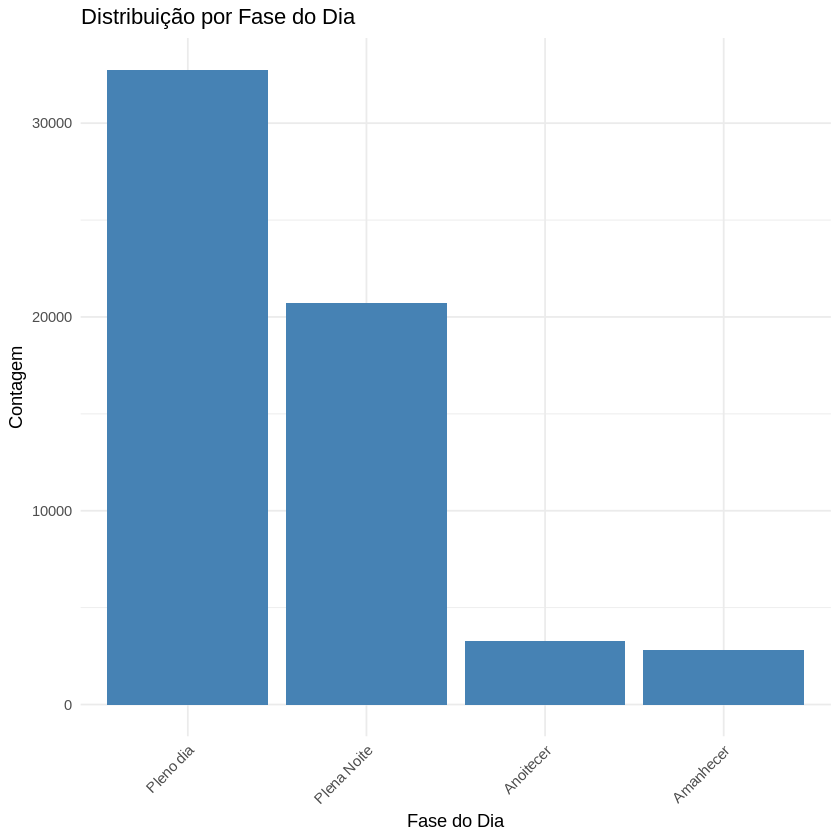

```r
dataset_ordenado <- dataset_limpo %>%
  count(fase_dia) %>%
  arrange(desc(n)) %>%
  mutate(fase_dia = factor(fase_dia, levels = fase_dia))

# Criando o gráfico com os dados ordenados
ggplot(dataset_ordenado, aes(x = fase_dia, y = n)) +
  geom_bar(stat = "identity", fill = "steelblue") +
  labs(title = "Distribuição por Fase do Dia",
       x = "Fase do Dia",
       y = "Contagem") +
  theme_minimal() +
  theme(axis.text.x = element_text(angle = 45, hjust = 1))

# Verificar percentual de cada fase do dia
frequencia_fase_dia <- dataset_limpo %>%
  group_by(fase_dia) %>%
  summarise(total = n()) %>%
  mutate(percentual = total / sum(total) * 100) %>%
  arrange(desc(total))

print(frequencia_fase_dia)
```

Verificamos que: 55% dos acidentes ocorrem em 'pleno dia'; 34,8% ocorrem em 'plena noite'; 5,49% ocorrem ao 'Anoitecer'; 4,73% ocorrem ao 'Amanhecer'.

## Que insights podem ser gerados sobre os tipos de acidentes predominantes e suas causas?

Vamos analisar quais os acidentes predominantes e suas causas:

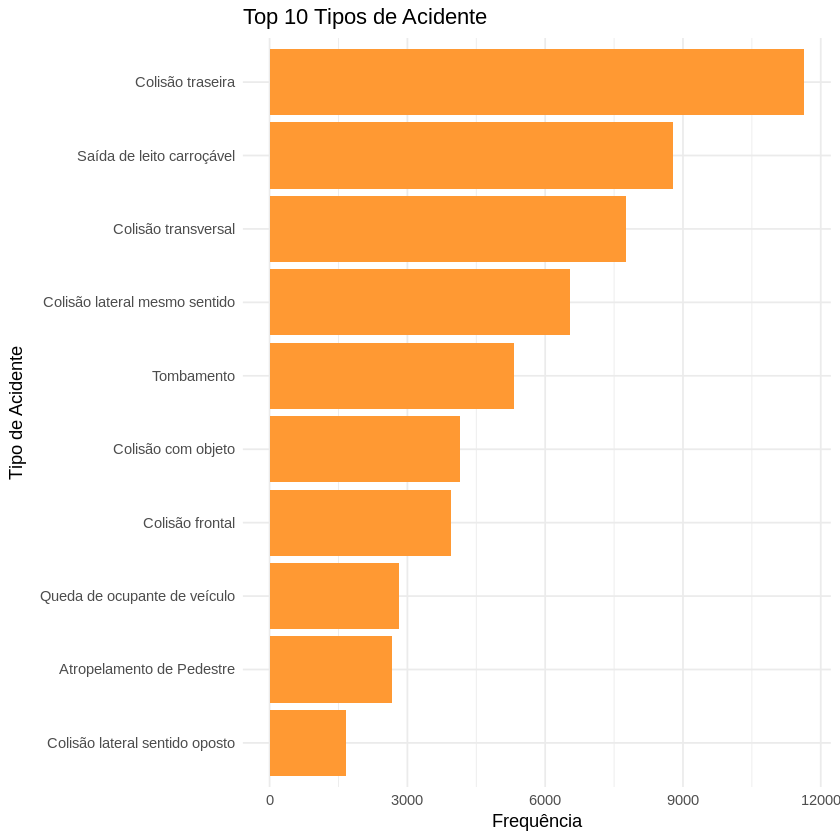

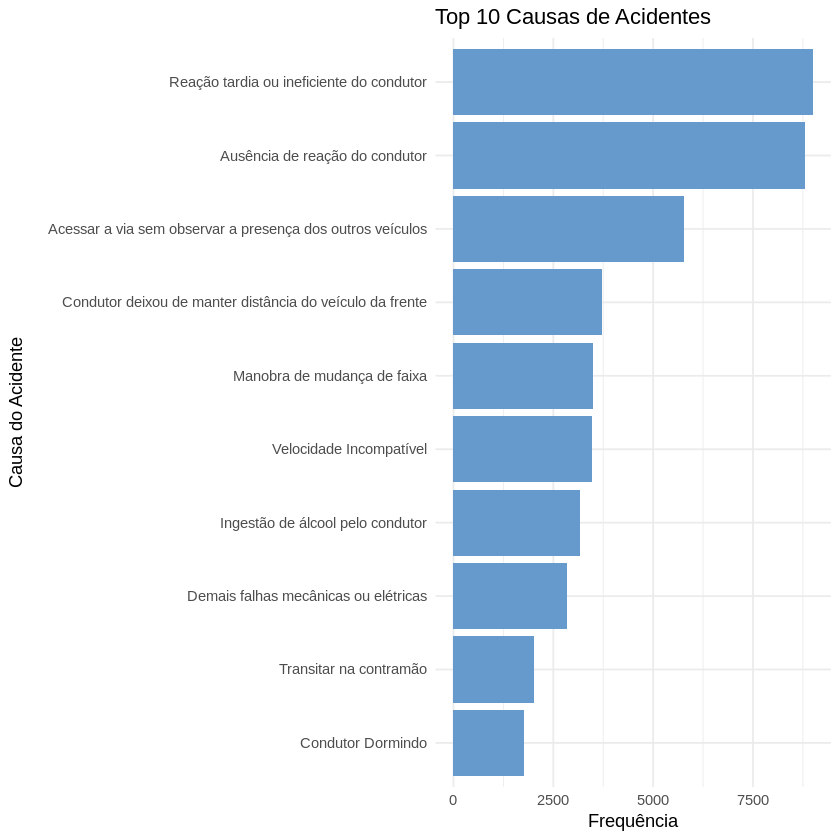

```r
# Verificar
library(dplyr)
library(ggplot2)

# Filtrar os 10 tipos de acidente mais comuns
top_tipos <- dataset %>%
  count(tipo_acidente, sort = TRUE) %>%
  slice_max(n, n = 10)  # ou head(10)

# Reordenar os fatores para o gráfico sair na ordem certa
top_tipos$tipo_acidente <- factor(top_tipos$tipo_acidente, levels = rev(top_tipos$tipo_acidente))

# Gráfico
ggplot(top_tipos, aes(x = tipo_acidente, y = n)) +
  geom_bar(stat = "identity", fill = "#FF9933") +
  coord_flip() +
  labs(
    title = "Top 10 Tipos de Acidente",
    x = "Tipo de Acidente",
    y = "Frequência"
  ) +
  theme_minimal()


library(dplyr)
library(ggplot2)

# Filtrar as 10 causas mais frequentes
top_causas <- dataset %>%
  count(causa_acidente, sort = TRUE) %>%
  slice_max(n, n = 10)  # ou head(10)

# Reordenar os fatores para o ggplot exibir em ordem decrescente
top_causas$causa_acidente <- factor(top_causas$causa_acidente, levels = rev(top_causas$causa_acidente))

# Gráfico
ggplot(top_causas, aes(x = causa_acidente, y = n)) +
  geom_bar(stat = "identity", fill = "#6699CC") +
  coord_flip() +
  labs(
    title = "Top 10 Causas de Acidentes",
    x = "Causa do Acidente",
    y = "Frequência"
  ) +
  theme_minimal()
```

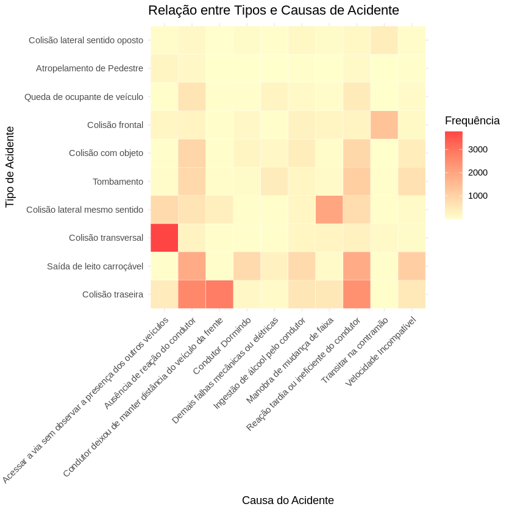

```r
# Ordenar tipo_acidente conforme a ordem em top_tipos
heat_data$tipo_acidente <- factor(
  heat_data$tipo_acidente,
  levels = top_tipos$tipo_acidente
)

# Heatmap com eixo Y ordenado
ggplot(heat_data, aes(x = causa_acidente, y = tipo_acidente, fill = n)) +
  geom_tile(color = "white") +
  scale_fill_gradient(low = "#FFFFCC", high = "#FF4444", name = "Frequência") +
  labs(
    title = "Relação entre Tipos e Causas de Acidente",
    x = "Causa do Acidente",
    y = "Tipo de Acidente"
  ) +
  theme_minimal() +
  theme(axis.text.x = element_text(angle = 45, hjust = 1))
```

Plotando um heatmap que correlaciona "Tipo de Acidente" vs "Causa do Acidente", ordenando o eixo Y de acordo com a frequência de ocorrência, podemos verificar quais são as principais causas para os principais tipos de colisão.

Podemos verificar que para 'Colisão traseira' (o mais frequente tipo de acidente), as seguintes causas que mais se relacionam são:

1. 'Condutor deixou de manter distância do veículo da frente';
2. 'Ausência de reação do condutor';
3. 'Reação tardia ou ineficiente do condutor'.

# Conclusão

## Principais Insights da Análise de Acidentes de Trânsito

1. **Distribuição Geográfica:** Minas Gerais é o estado com maior número de acidentes no Brasil;
2. **Condições Climáticas:** 71,56% dos acidentes de trânsito ocorrem em condições climáticas favoráveis (céu claro ou sol), o que sugere que as boas condições de visibilidade não necessariamente resultam em menor incidência de acidentes.
3. **Horário dos Acidentes:** A fase do dia tem influência significativa na ocorrência de acidentes:
- 55% ocorrem em pleno dia;
- 34,8% ocorrem em plena noite;
- 5,49% acontecem ao anoitecer;
- 4,73% acontecem ao amanhecer.

Isso indica que, apesar da melhor visibilidade durante o dia, é quando ocorre a maior parte dos acidentes, possivelmente devido ao maior volume de tráfego.

1. **Tipos de Acidentes Predominantes:** A análise identificou a colisão traseira como o tipo mais frequente de acidente.
1. **Principais Causas de Acidentes:** As causas mais comuns estão relacionadas ao comportamento do condutor, com destaque para:
- Não manter distância segura do veículo à frente;
- Ausência de reação do condutor;
- Reação tardia ou ineficiente do condutor

Os dados sugerem que fatores humanos têm maior impacto na ocorrência de acidentes do que condições ambientais ou de infraestrutura.

Estas conclusões podem ser úteis para direcionar campanhas de educação no trânsito, focando no comportamento humano, especialmente em estados com maior incidência de acidentes como Minas Gerais e Santa Catarina e Paraná.